# Assignment 4: Centrality and efficiency

### Data Transformation

Processing time of each application is calculated from filing_date to patent_issue_dat or patent_abandon_date

```r
applications$filing_date <- as.Date(applications$filing_date)
#applications$application_result_date <- as.Date(applications$application_result_date, format = "%Y-%m-%d")
applications$application_result_date <- ifelse(!is.na(applications$patent_issue_date),
                                               as.Date(applications$patent_issue_date),
                                               as.Date(applications$abandon_date))
applications$application_result_date <- as.Date(applications$application_result_date,
                                                format = "%Y-%m-%d", origin = "1970-01-01")
applications$application_processing_time <- as.integer(difftime
                                                       (applications$application_result_date,
                                                         applications$filing_date, units = "days"))
```

```r
# Convert node_id column in result_df to double
result_df$node_id <- as.numeric(result_df$node_id)

process_data <- select(applications, examiner_id, examiner_art_unit, tc, race, tenure_days, gender, application_processing_time)
process_data$examiner_id <- as.numeric(process_data$examiner_id)

# Perform left join
# join process_data and result_df by examiner_id and node_id, respectively
# remove rows with NaN values in result_df
result_df <- result_df[complete.cases(result_df),]
# remove rows with NaN values in process_data
process_data <- process_data[complete.cases(process_data),]
process_data$tc = as.character(process_data$tc)
joined_data <- left_join(process_data, result_df, by = c("examiner_id" = "node_id"))
# remove rows with NAs
joined_data <- na.omit(joined_data)
```

```r
joined_data$tc <- factor(joined_data$tc)
joined_data$race <- factor(joined_data$race)
joined_data$gender <- factor(joined_data$gender)
joined_data[, c("tenure_days", "degree", "betweenness", "closeness")] <- scale(joined_data[, c("tenure_days", "degree", "betweenness", "closeness")])
kable(head(joined_data,10), caption = "Final table")
```

Final table

| examiner_id | examiner_art_unit | tc | race | tenure_days | gender | application_processing_time | degree | betweenness | closeness |
| --- | --- | --- | --- | --- | --- | --- | --- | --- | --- |
| 63213 | 1752 | 1700 | white | 0.6296442 | female | -1170 | -0.4888784 | -0.4512543 | -0.1017199 |
| 73788 | 1648 | 1600 | white | 0.6107444 | female | 1481 | -0.4579314 | -0.4641175 | -0.1019633 |
| 77294 | 1762 | 1700 | white | 0.6121983 | male | 261 | 0.6252166 | 0.1292200 | -0.1018691 |
| 77112 | 1755 | 1700 | white | 0.6340057 | female | 644 | 0.1919574 | 1.8594665 | -0.1017974 |
| 92931 | 1642 | 1600 | white | 0.6383672 | female | 294 | -0.5198255 | -0.4697439 | -0.1019925 |
| 75406 | 1733 | 1700 | white | 0.6281904 | male | 693 | 0.7799520 | 0.9623240 | -0.1018076 |
| 63176 | 1722 | 1700 | white | 0.6165598 | male | 1048 | 2.2963591 | 3.8243426 | -0.1017815 |
| 59816 | 1751 | 1700 | white | 0.6340057 | male | 2387 | -0.4579314 | -0.2529363 | -0.1017278 |
| 64507 | 1644 | 1600 | white | 0.6063829 | male | 1210 | -0.3960372 | -0.3435523 | -0.1018607 |
| 82563 | 1714 | 1700 | white | 0.6340057 | male | 1946 | -0.4579314 | -0.4208963 | -0.1018572 |

```r
library(dplyr)
library(caret)
library(fastDummies)
encoded_data <- joined_data %>%
  dummy_cols(select_columns = c("gender", "race", "tc"))
kable(head(encoded_data,10), caption = " Transformed application data")
```

Transformed application data

| examiner_id | examiner_art_unit | tc | race | tenure_days | gender | application_processing_time | degree | betweenness | closeness | gender_female | gender_male | race_Asian | race_black | race_Hispanic | race_other | race_white | tc_1600 | tc_1700 | tc_2100 | tc_2400 |
| --- | --- | --- | --- | --- | --- | --- | --- | --- | --- | --- | --- | --- | --- | --- | --- | --- | --- | --- | --- | --- |
| 63213 | 1752 | 1700 | white | 0.6296442 | female | -1170 | -0.4888784 | -0.4512543 | -0.1017199 | 1 | 0 | 0 | 0 | 0 | 0 | 1 | 0 | 1 | 0 | 0 |
| 73788 | 1648 | 1600 | white | 0.6107444 | female | 1481 | -0.4579314 | -0.4641175 | -0.1019633 | 1 | 0 | 0 | 0 | 0 | 0 | 1 | 1 | 0 | 0 | 0 |
| 77294 | 1762 | 1700 | white | 0.6121983 | male | 261 | 0.6252166 | 0.1292200 | -0.1018691 | 0 | 1 | 0 | 0 | 0 | 0 | 1 | 0 | 1 | 0 | 0 |
| 77112 | 1755 | 1700 | white | 0.6340057 | female | 644 | 0.1919574 | 1.8594665 | -0.1017974 | 1 | 0 | 0 | 0 | 0 | 0 | 1 | 0 | 1 | 0 | 0 |
| 92931 | 1642 | 1600 | white | 0.6383672 | female | 294 | -0.5198255 | -0.4697439 | -0.1019925 | 1 | 0 | 0 | 0 | 0 | 0 | 1 | 1 | 0 | 0 | 0 |
| 75406 | 1733 | 1700 | white | 0.6281904 | male | 693 | 0.7799520 | 0.9623240 | -0.1018076 | 0 | 1 | 0 | 0 | 0 | 0 | 1 | 0 | 1 | 0 | 0 |
| 63176 | 1722 | 1700 | white | 0.6165598 | male | 1048 | 2.2963591 | 3.8243426 | -0.1017815 | 0 | 1 | 0 | 0 | 0 | 0 | 1 | 0 | 1 | 0 | 0 |
| 59816 | 1751 | 1700 | white | 0.6340057 | male | 2387 | -0.4579314 | -0.2529363 | -0.1017278 | 0 | 1 | 0 | 0 | 0 | 0 | 1 | 0 | 1 | 0 | 0 |
| 64507 | 1644 | 1600 | white | 0.6063829 | male | 1210 | -0.3960372 | -0.3435523 | -0.1018607 | 0 | 1 | 0 | 0 | 0 | 0 | 1 | 1 | 0 | 0 | 0 |
| 82563 | 1714 | 1700 | white | 0.6340057 | male | 1946 | -0.4579314 | -0.4208963 | -0.1018572 | 0 | 1 | 0 | 0 | 0 | 0 | 1 | 0 | 1 | 0 | 0 |

### Creating linear regression models

```r
model <- lm(application_processing_time ~ tc_1700 + tc_2100 + tc_2400 + race_Asian + race_black + race_Hispanic + race_other + tenure_days + gender_female + degree + betweenness + closeness, data = encoded_data)
summary(model)
```

```
##
## Call:
## lm(formula = application_processing_time ~ tc_1700 + tc_2100 +
##     tc_2400 + race_Asian + race_black + race_Hispanic + race_other +
##     tenure_days + gender_female + degree + betweenness + closeness,
##     data = encoded_data)
##
## Residuals:
##     Min      1Q  Median      3Q     Max
## -7416.1  -417.7  -105.2   289.8  4965.8
##
## Coefficients:
##                Estimate Std. Error t value Pr(>|t|)
## (Intercept)   1134.9993     1.5881 714.687  < 2e-16 ***
## tc_1700        -26.0716     1.7525 -14.877  < 2e-16 ***
## tc_2100        189.9264     2.0455  92.849  < 2e-16 ***
## tc_2400        259.9813     2.3063 112.729  < 2e-16 ***
## race_Asian      -3.7885     1.5380  -2.463   0.0138 *
## race_black     -29.6865     3.6603  -8.110 5.05e-16 ***
## race_Hispanic   28.5915     4.5483   6.286 3.25e-10 ***
## race_other     179.5359    19.1086   9.396  < 2e-16 ***
## tenure_days    -17.2730     0.6702 -25.774  < 2e-16 ***
## gender_female   30.7230     1.4573  21.083  < 2e-16 ***
## degree           1.1913     0.8485   1.404   0.1603
## betweenness      0.6542     0.8478   0.772   0.4403
## closeness       -0.7918     0.6533  -1.212   0.2255
## ---
## Signif. codes:  0 '***' 0.001 '**' 0.01 '*' 0.05 '.' 0.1 ' ' 1
##
## Residual standard error: 616.1 on 902838 degrees of freedom
## Multiple R-squared:  0.03574,    Adjusted R-squared:  0.03573
## F-statistic:  2789 on 12 and 902838 DF,  p-value: < 2.2e-16
```

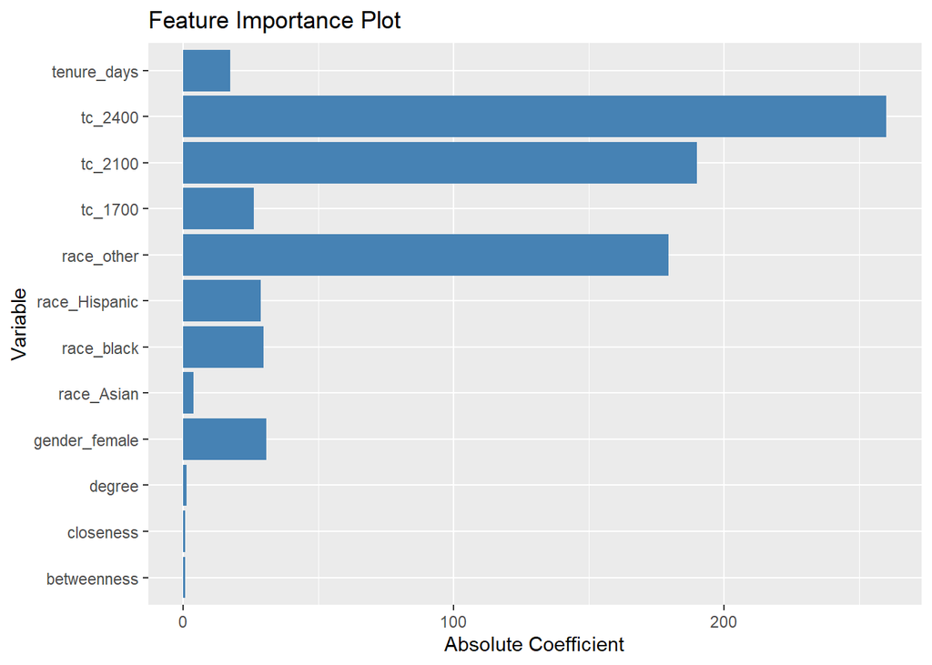

```r
library(ggplot2)
# Create a data frame of coefficients and their corresponding variables
coef_df <- data.frame(variable = names(model$coefficients)[-1],
                      coefficient = abs(model$coefficients[-1]))
# Create a bar plot of the absolute values of the coefficients
ggplot(coef_df, aes(x = variable, y = coefficient)) +
  geom_bar(stat = "identity", fill = "steelblue") +
  coord_flip() +
  xlab("Variable") +
  ylab("Absolute Coefficient") +
  ggtitle("Feature Importance Plot")
```

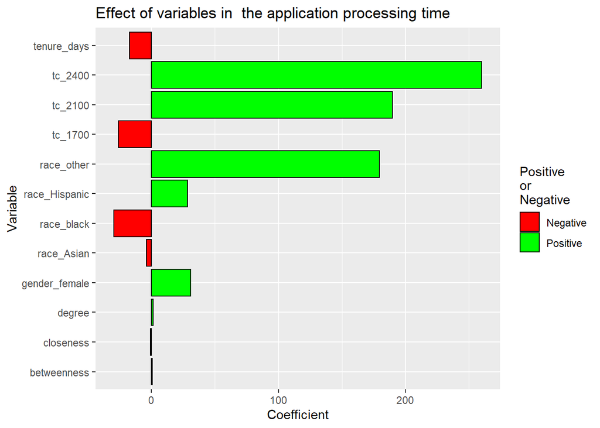

```r
# Extract the coefficients and their corresponding variables
coef_df <- data.frame(variable = names(model$coefficients)[-1],
                      coefficient = model$coefficients[-1])

# Create a bar chart showing the positive and negative impact of variables
library(ggplot2)
ggplot(coef_df, aes(x = variable, y = coefficient, fill = coefficient > 0)) +
  geom_bar(stat = "identity", color = "black") +
  scale_fill_manual(values = c("red", "green"), labels = c("Negative", "Positive")) +
  coord_flip() +
  labs(x = "Variable", y = "Coefficient", fill = "Positive\nor\nNegative") +
  ggtitle("Effect of variables in  the application processing time")
```

- Tenure days have negative impact on processing time. Higher the tenure date lower is the processing time.
- The various centrality measures are not important variables when predicting the application processing times
- The application processing time is higher for females compared to males
- The processing times for tc_2400 and tc_2100 are higher while that of tc_1700 is lower
- The processing time for the asian and black race is lower compared to hispanic and other race